# Machine Learning Project-ELM

Edward May

June 7, 2018

```r
knitr::opts_chunk$set(echo = TRUE)
setwd("~/Coursera/Machine Learning/Project")
```

## Background

Using devices such as Jawbone Up, Nike FuelBand, and Fitbit it is now possible to collect a large amount of data about personal activity relatively inexpensively. These type of devices are part of the quantified self movement – a group of enthusiasts who take measurements about themselves regularly to improve their health, to find patterns in their behavior, or because they are tech geeks. One thing that people regularly do is quantify how much of a particular activity they do, but they rarely quantify how well they do it. In this project, your goal will be to use data from accelerometers on the belt, forearm, arm, and dumbell of 6 participants. They were asked to perform barbell lifts correctly and incorrectly in 5 different ways. More information is available from the website here: http://groupware.les.inf.puc-rio.br/har (see the section on the Weight Lifting Exercise Dataset).

### Load data

```r
testing <- read.csv("pml-testing.csv")
training <- read.csv("pml-training.csv")
#Subset training to only the columns that testing uses
t1 <- training[,!is.na(testing[2,])]
library(caret)
##Split the data set for cross-validation
inTrain <- createDataPartition(y=t1$classe,p=.9,list=FALSE)
training <- t1[inTrain,]
testset <- t1[-inTrain,]
dim(training)
```

```
## [1] 17662    60
```

```r
dim(testset)
```

```
## [1] 1960   60
```

## Variable Correlation

are the variables highly correlated?

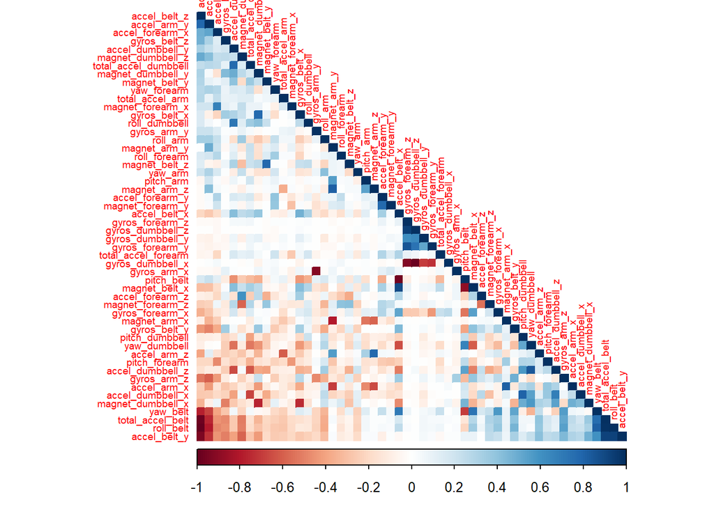

```r
library(corrplot)
corMT <- cor(training[,8:59])
corrplot(corMT, method="color", type="lower", order="FPC",tl.cex = .6)
```

Looking through the data, it would probably be best if we could compare the shapes of the variable plots through the time of each motion since that is probably how the motions were rated as a whole, but the test data only has a single row of variables, not time series plots, so that will not help.

We will fit a random forest model and iterate 50 times. Random forest combines decision trees and bagging to obtain a slightly better solution.

```r
library(randomForest)
```

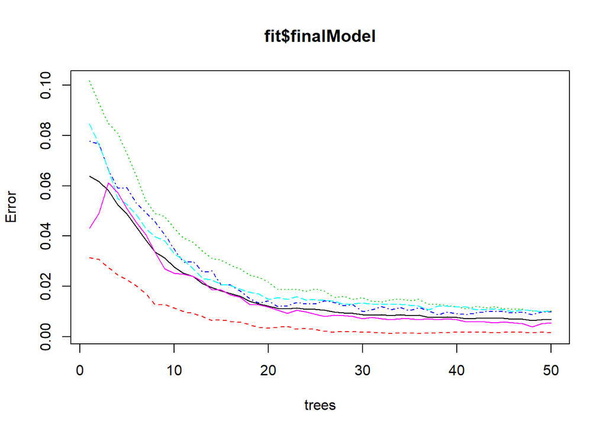

```r
# Since the data is sorted by the classe, we can't use the time or X values
# as those data are not available in the testing data set
if(!file.exists("fit.rds")) {
    set.seed(123)
    fit <- train(classe~.,data=training[,8:60],method="rf",ntree=50,
                 trControl=trainControl(method="cv", number = 10,
                                        classProbs = TRUE,
                                        savePredictions = TRUE),
             verbose=TRUE)
    saveRDS(fit, file='fit.rds')
} else {
    fit <- readRDS('fit.rds')
}

plot(fit$finalModel)
```

```r
fit$finalModel
```

```
##
## Call:
##  randomForest(x = x, y = y, ntree = 50, mtry = param$mtry, verbose = TRUE)
##                Type of random forest: classification
##                      Number of trees: 50
## No. of variables tried at each split: 27
##
##         OOB estimate of  error rate: 0.68%
## Confusion matrix:
##      A    B    C    D    E class.error
## A 5014    6    0    0    2 0.001592991
## B   27 3383    7    1    0 0.010239906
## C    1   14 3050   14    1 0.009740260
## D    0    1   25 2866    3 0.010017271
## E    0    1    7   10 3229 0.005543579
```

```r
fit$results
```

```
##   mtry  Accuracy     Kappa  AccuracySD     KappaSD
## 1    2 0.9929229 0.9910471 0.002138427 0.002705269
## 2   27 0.9941683 0.9926228 0.002118623 0.002680427
## 3   52 0.9870906 0.9836676 0.003913712 0.004954666
```

This was sucessful to 99.4% accuracy!

## Important Variables

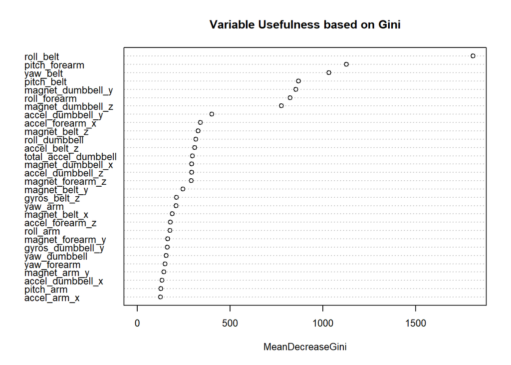

```r
varImpPlot(fit$finalModel,
  sort = TRUE,  cex=.8,
  main="Variable Usefulness based on Gini")
```

## Cross-validation:

```r
predTest <- predict(fit, testset)
confMat <- confusionMatrix(predTest, testset$classe)
confMat
```

```
## Confusion Matrix and Statistics
##
##           Reference
## Prediction   A   B   C   D   E
##          A 558   1   0   0   0
##          B   0 378   1   0   0
##          C   0   0 341   0   0
##          D   0   0   0 321   0
##          E   0   0   0   0 360
##
## Overall Statistics
##
##                Accuracy : 0.999
##                  95% CI : (0.9963, 0.9999)
##     No Information Rate : 0.2847
##     P-Value [Acc > NIR] : < 2.2e-16
##
##                   Kappa : 0.9987
##  Mcnemar's Test P-Value : NA
##
## Statistics by Class:
##
##                      Class: A Class: B Class: C Class: D Class: E
## Sensitivity            1.0000   0.9974   0.9971   1.0000   1.0000
## Specificity            0.9993   0.9994   1.0000   1.0000   1.0000
## Pos Pred Value         0.9982   0.9974   1.0000   1.0000   1.0000
## Neg Pred Value         1.0000   0.9994   0.9994   1.0000   1.0000
## Prevalence             0.2847   0.1934   0.1745   0.1638   0.1837
## Detection Rate         0.2847   0.1929   0.1740   0.1638   0.1837
## Detection Prevalence   0.2852   0.1934   0.1740   0.1638   0.1837
## Balanced Accuracy      0.9996   0.9984   0.9985   1.0000   1.0000
```

## Example shape functions for the choice being “A”

[output not shown]

[figure not shown]

```r
answer <- data.frame(input=1:20,classe=predict(fit,testing),
                prob=apply(predict(fit,testing,type = "prob"),1,max)
)
print(answer)
```

```
##    input classe prob
## 1      1      B 0.82
## 2      2      A 0.98
## 3      3      B 0.72
## 4      4      A 1.00
## 5      5      A 0.96
## 6      6      E 0.88
## 7      7      D 0.86
## 8      8      B 0.82
## 9      9      A 1.00
## 10    10      A 1.00
## 11    11      B 0.88
## 12    12      C 0.76
## 13    13      B 0.96
## 14    14      A 1.00
## 15    15      E 0.96
## 16    16      E 0.96
## 17    17      A 0.98
## 18    18      B 0.84
## 19    19      B 0.92
## 20    20      B 1.00
```